# Assignment 4

October 19, 2020

```r
library(tigris)
library(tidyverse)
library(tidycensus)
library(sf)
library(leaflet)
library(StatMatch)

census_api_key("c8aa67e4086b4b5ce3a8717f59faa9a28f611dab")
```

```r
ca_counties <- counties("CA", cb=T, progress_bar = F)

bay_county_names <-
  c(
    "Alameda",
    "Contra Costa",
    "Marin",
    "Napa",
    "San Francisco",
    "San Mateo",
    "Santa Clara",
    "Solano",
    "Sonoma"
  )

bay_counties <-
  ca_counties %>%
  filter(NAME %in% bay_county_names)

ca_pumas <-
  pumas("CA", cb = T, progress_bar = F)

bay_pumas <-
  ca_pumas %>%
  st_centroid() %>%
  .[bay_counties, ] %>%
  st_set_geometry(NULL) %>%
  left_join(ca_pumas %>% select(GEOID10)) %>%
  st_as_sf()
```

```r
leaflet() %>%
  addProviderTiles(providers$CartoDB.Positron) %>%
  addPolygons(
    data = bay_pumas,
    weight = 1,
    color = "gray",
    label = ~paste0(PUMACE10)
    ) %>%
  addMarkers(
    lng = -122.3519,
    lat = 37.8168
    )
```

[interactive chart not shown]

```r
pums_bike <-
  2012:2014 %>%
  map_dfr(function(year){
    get_pums(
      variables = c(
        "PUMA",
        "JWTR"
      ),
      state = "CA",
      year = year,
      survey = "acs1",
      recode = F
    ) %>%
      mutate(
        bike = ifelse(
          JWTR == 9,
          PWGTP,
          0
        ),
        PUMA = PUMA %>% str_pad(5,"left","0")
      ) %>%
      group_by(PUMA) %>%
      summarize(
        bike = sum(bike),
        year = year
      )
  })
```

```r
pums_bike_clean <-
  pums_bike %>%
  pivot_wider(
    names_from = year,
    values_from = bike
  ) %>%
  filter(PUMA %in% bay_pumas$PUMACE10)
```

```r
obs_matrix <-
  pums_bike_clean %>%
  select(`2012`,`2013`) %>%
  as.matrix()

dist_matrix <- mahalanobis.dist(obs_matrix)

rownames(dist_matrix) <- pums_bike_clean$PUMA
colnames(dist_matrix) <- pums_bike_clean$PUMA

match <- dist_matrix["00102",] %>%
  as.data.frame() %>%
  rownames_to_column() %>%
  rename(
    PUMA = rowname,
    match = "."
  ) %>%
  right_join(
    pums_bike_clean
  ) %>%
  arrange(match) %>%
  .[1:11, ] %>%
  left_join(bay_pumas %>% select(PUMA = PUMACE10)) %>%
  st_as_sf()

leaflet() %>%
  addTiles() %>%
  addProviderTiles(providers$CartoDB.Positron) %>%
  addPolygons(
    data = match[1, ],
    color = "red",
    label = ~PUMA
  ) %>%
  addPolygons(
    data = match[-1, ],
    label = ~PUMA
  )
```

[interactive chart not shown]

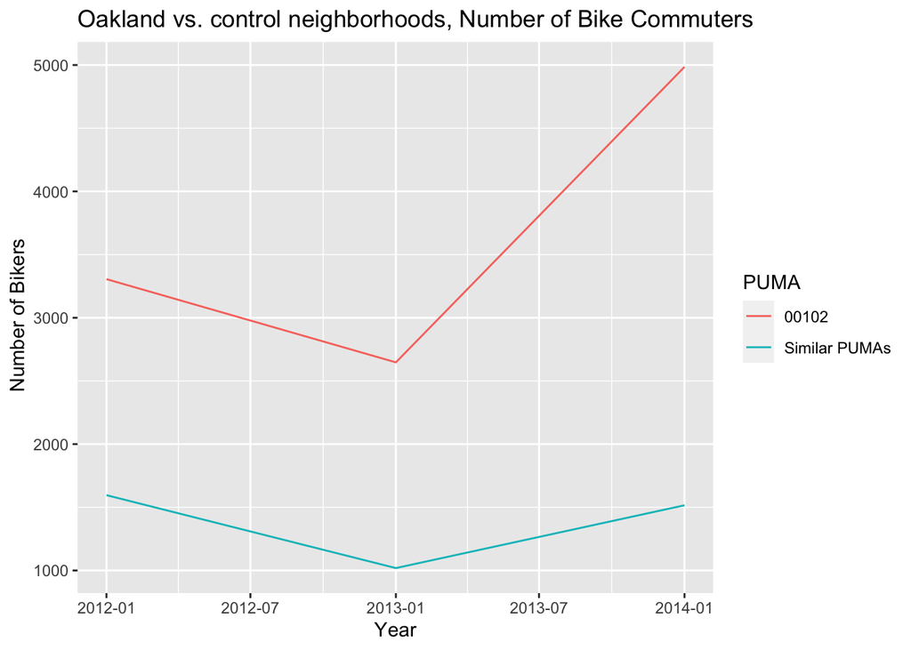

```r
match_pumas <-
  match[-1,] %>%
  st_set_geometry(NULL) %>%
  select(-match) %>%
  pivot_longer(
    -PUMA,
    names_to = "year",
    values_to = "bike"
  ) %>%
  group_by(
    year
  ) %>%
  summarize(
    bike = mean(bike),
    PUMA = "Similar PUMAs"
  )

treatment_puma <-
  match[1,] %>%
  select(-match) %>%
  st_set_geometry(NULL) %>%
  pivot_longer(
    -PUMA,
    names_to = "year",
    values_to = "bike"
  )

rbind(
  treatment_puma,
  match_pumas
) %>%
  mutate(
    year = year %>% paste0(.,"-01-01") %>%  as.Date()
  ) %>%
  ggplot(
    aes(
      x = year,
      y = bike,
      color = PUMA
    )
  ) +
  geom_line() +
  geom_vline(xintercept = 2014, linetype = "dashed") +
  labs(
    title = "Oakland vs. control neighborhoods, Number of Bike Commuters",
    x = "Year",
    y = " Number of Bikers"
  )
```

```r
bike_work_oakland <-
  match %>%
  st_set_geometry(NULL) %>%
  select(-match) %>%
  pivot_longer(
    -PUMA,
    names_to = "year",
    values_to = "bike"
  ) %>%
  mutate(
    year = year %>% as.numeric(),
    time = ifelse(year == 2014, 1, 0),
    treated = ifelse(PUMA == "00102", 1, 0)
  )

did_reg_oakland <- lm(bike ~ treated*time, data = bike_work_oakland)

summary(did_reg_oakland)
```

```
##
## Call:
## lm(formula = bike ~ treated * time, data = bike_work_oakland)
##
## Residuals:
##     Min      1Q  Median      3Q     Max
## -1209.4  -629.5  -177.4   325.6  3271.6
##
## Coefficients:
##              Estimate Std. Error t value Pr(>|t|)
## (Intercept)    1307.5      231.9   5.638 4.31e-06 ***
## treated        1669.0      769.1   2.170   0.0383 *
## time            208.9      401.7   0.520   0.6069
## treated:time   1799.6     1332.1   1.351   0.1872
## ---
## Signif. codes:  0 '***' 0.001 '**' 0.01 '*' 0.05 '.' 0.1 ' ' 1
##
## Residual standard error: 1037 on 29 degrees of freedom
## Multiple R-squared:  0.353,  Adjusted R-squared:  0.2861
## F-statistic: 5.275 on 3 and 29 DF,  p-value: 0.005006
```

This analysis explores the change in the number of people who bike to work after the completion of the eastern span replacement of the San Francisco-Oakland Bay Bridge in September of 2013. The eastern span of the bridge crosses the San Francisco Bay between Yerba Buena Island and Oakland, and the replacement includes a new bicycle route. I’m interested in exploring the impact that the replacement had on the number of people who bike to work, specifically those living in the Oakland area where the eastern span of the bridge ends. Since the replacement was completed in September of 2013, I used the year 2014 as the “treatment” year and the years 2012-2013 as the “pre-treatment” years. The regression suggests that ~1800 more people in the Oakland area rode their bike to work during the treatment year, however this increase is not significant. Based on the line chart for Oakland vs. control neighborhoods, it’s clear that throughout the pre-treatment and treatment years, the Oakland area has always had a larger number of people who bike to work compared to similar PUMAS, and the treatment does not appear to cause any significant changes beyond what would have likely occurred without the treatment.

```r
bike_work_more_pumas <-
  match %>%
  st_set_geometry(NULL) %>%
  select(-match) %>%
  pivot_longer(
    -PUMA,
    names_to = "year",
    values_to = "bike"
  ) %>%
  mutate(
    year = year %>% as.numeric(),
    time = ifelse(year == 2014, 1, 0),
    treated = ifelse(PUMA == c("00102", "00103", "07501", "07502"), 1, 0)
  )

did_reg_more_pumas <- lm(bike ~ treated*time, data = bike_work_more_pumas)

summary(did_reg_more_pumas)
```

```
##
## Call:
## lm(formula = bike ~ treated * time, data = bike_work_more_pumas)
##
## Residuals:
##     Min      1Q  Median      3Q     Max
## -1634.6  -687.6   -92.5   338.5  3043.4
##
## Coefficients:
##              Estimate Std. Error t value Pr(>|t|)
## (Intercept)    1284.5      262.2   4.899 3.36e-05 ***
## treated        1922.0      869.7   2.210   0.0351 *
## time            657.1      470.7   1.396   0.1733
## treated:time  -2526.1     1263.6  -1.999   0.0550 .
## ---
## Signif. codes:  0 '***' 0.001 '**' 0.01 '*' 0.05 '.' 0.1 ' ' 1
##
## Residual standard error: 1173 on 29 degrees of freedom
## Multiple R-squared:  0.1728, Adjusted R-squared:  0.08724
## F-statistic:  2.02 on 3 and 29 DF,  p-value: 0.1331
```

Overall, it may be that the number of people who bike to work is not the important variable to measure. It’s possible that instead of increasing the number of bikers, the treatment actually increased the number of people who use another means of transportation to get to work, such as their personal vehicle. It’s also possible that more people are using the new bike route, but just not as their means of transportation to work. The analysis is limited in that regard, because it does not capture biking for recreation. Another limitation of this analysis is that I did not match based on any other variables other than means of transportation to work, so future analyses could also control for additional variables such as income and demographics.